# Lecture 11.1 DL Applications in Civil Engineering

Harnessing AI for Engineering Decisions: A Case Study in Housing Price Prediction

Author

Dr. W.Wu@UTC for ENCE 2530

## Introduction

The goals of this lab is to apply both deep learning and multiple variable regression techniques to predict housing prices using the provided Ames Housing dataset.

## Prompts

**Original prompts:**

Develop two deep learning models using Python and TensorFlow (PyTorch is a good alternative with less issue of compatibility) to train artificial neural networks (ANN) for predicting housing prices. The first model will use selected features such as Age, Gr Liv Area, Lot Area, Overall Qual, and Neighborhood. The second model will utilize all features in the dataset. Some features may be categorical, so encoding techniques will be necessary to convert the data. Additionally, create a multi-regression model using the selected features and the target to predict housing prices. Plot loss vs epoch for training and validation. Finally, compare the performance of the three models using 5 housing data from the dataset, that is to compare the housing prices predicted from the three models and compare with the actual saleprice, show comparison in a table. The 5 housing data used for testing should not be used in training or validation.

**Additional prompts:**

I’ve attached the Python code used to train two deep learning models and one regression model for predicting housing prices using over 2,000 housing data records. One deep learning model was developed using all available features, while the other utilized only selected essential features. Based on the loss versus epochs for both training and validation data, there doesn’t appear to be an overfitting issue. However, the performance of the deep learning models, particularly the one using all features, is unexpectedly worse than the regression model. Since collecting additional data is not feasible, what strategies could improve the performance of the deep learning models? Morover, please modify the codes such that we can rate the performance of the three models based on their percentage difference from the actual price? Could you adjust the attached Python code accordingly?

Other changes made: increase the test samples from 5 to 50 (at least 30)

AI tool used: Multiple AI Tools

### **Step 1: Data Preprocessing**

#### **1.1 Load and Prepare Data**

```python
import pandas as pd
import numpy as np
from sklearn.model_selection import train_test_split
from sklearn.preprocessing import StandardScaler, OneHotEncoder
from sklearn.compose import ColumnTransformer
from sklearn.pipeline import Pipeline
from sklearn.impute import SimpleImputer
from sklearn.linear_model import LinearRegression
import tensorflow as tf
from tensorflow import keras
from tensorflow.keras import regularizers
from tensorflow.keras.callbacks import EarlyStopping
import matplotlib.pyplot as plt
import joblib

# Load dataset
data = pd.read_excel('AmesHousing.xlsx', sheet_name='AmesHousing')

# Create 'Age' feature
data['Age'] = data['Yr Sold'] - data['Year Built']

# Split into train + val and test sets (50 samples)
test_data = data.sample(n=50, random_state=42)
train_val_data = data.drop(test_data.index)

# Features and target
X_test = test_data.drop('SalePrice', axis=1)
y_test = test_data['SalePrice']

# Selected Features Setup (unchanged)
selected_features = ['Age', 'Gr Liv Area', 'Lot Area', 'Overall Qual', 'Neighborhood']
target = 'SalePrice'
X_selected = train_val_data[selected_features]
y_selected = train_val_data[target]
```

#### **1.2 Preprocess Selected Features (Age, Gr Liv Area, Lot Area, Overall Qual, Neighborhood)**

```python
# Selected Features Setup
selected_features = ['Age', 'Gr Liv Area', 'Lot Area', 'Overall Qual', 'Neighborhood']
target = 'SalePrice'
X_selected = train_val_data[selected_features]
y_selected = train_val_data[target]

preprocessor_selected = ColumnTransformer(
    transformers=[
        ('num', StandardScaler(), ['Age', 'Gr Liv Area', 'Lot Area', 'Overall Qual']),
        ('cat', OneHotEncoder(sparse_output=False), ['Neighborhood'])
    ])
X_selected_processed = preprocessor_selected.fit_transform(X_selected)
```

#### **1.3 Preprocess All Features**

```python
# All Features Setup with Imputation
X_all = train_val_data.drop('SalePrice', axis=1)
y_all = train_val_data['SalePrice']


# Prepare a default input (a “default row”) with values for every feature for later deployment usage

# Ensure X_all is defined as your DataFrame with all features (including 'Order')
# Identify numerical and categorical columns (these should include 'Order' if it exists)
# If "Order" is the index, reset it so that it becomes a column
# if X_all.index.name == 'Order' or 'Order' not in X_all.columns:
#     X_all = X_all.reset_index()

# Identify numerical and categorical columns (now including "Order" if it exists)
categorical_cols = X_all.select_dtypes(include=['object']).columns
numerical_cols = X_all.select_dtypes(exclude=['object']).columns

# Compute default values for each feature in X_all
default_values = {}
for col in X_all.columns:
    if col in numerical_cols:
        default_values[col] = X_all[col].median()
    elif col in categorical_cols:
        default_values[col] = X_all[col].mode().iloc[0]
    else:
        default_values[col] = ''  # or another appropriate default

# Convert the dictionary to a one-row DataFrame
default_all_df = pd.DataFrame([default_values])
# Reindex to ensure exact column order as in X_all
default_all_df = default_all_df.reindex(columns=X_all.columns)

# Save the complete default row to a CSV file
default_all_df.to_csv('default_all_features.csv', index=False)


# Define pipelines for numerical and categorical features with imputation
num_pipeline = Pipeline([
    ('imputer', SimpleImputer(strategy='median')),
    ('scaler', StandardScaler())
])
cat_pipeline = Pipeline([
    ('imputer', SimpleImputer(strategy='most_frequent')),
    ('onehot', OneHotEncoder(sparse_output=False, handle_unknown='ignore'))
])

preprocessor_all = ColumnTransformer(
    transformers=[
        ('num', num_pipeline, numerical_cols),
        ('cat', cat_pipeline, categorical_cols)
    ])
X_all_processed = preprocessor_all.fit_transform(X_all)

# Split data into train and validation sets
X_train_selected, X_val_selected, y_train_selected, y_val_selected = train_test_split(
    X_selected_processed, y_selected, test_size=0.2, random_state=42)
X_train_all, X_val_all, y_train_all, y_val_all = train_test_split(
    X_all_processed, y_all, test_size=0.2, random_state=42)
```

### **Step 2: Model Development**

#### **2.2 ANN with Selected Features**

```python
# Set up early stopping callback
early_stop = EarlyStopping(monitor='val_loss', patience=20, restore_best_weights=True)

### Modified ANN with Selected Features
model_selected = keras.Sequential([
    keras.layers.Dense(64, activation='relu', input_shape=(X_train_selected.shape[1],),
                       kernel_regularizer=regularizers.l2(0.001)),
    keras.layers.Dropout(0.2),
    keras.layers.Dense(32, activation='relu', kernel_regularizer=regularizers.l2(0.001)),
    keras.layers.Dropout(0.2),
    keras.layers.Dense(1)
])
#model_selected.compile(optimizer=keras.optimizers.Adam(learning_rate=0.001), loss='mse')
model_selected.compile(optimizer='adam', loss=tf.keras.losses.MeanSquaredError(reduction='sum_over_batch_size'))

history_selected = model_selected.fit(
    X_train_selected, y_train_selected,
    validation_data=(X_val_selected, y_val_selected),
    epochs=200, batch_size=32, callbacks=[early_stop], verbose=0)

model_selected.save('model_selected.h5')
```

#### **2.2 ANN with All Features**

```python
### Modified ANN with All Features with Imputation
model_all = keras.Sequential([
    keras.layers.Dense(128, activation='relu', input_shape=(X_train_all.shape[1],),
                       kernel_regularizer=regularizers.l2(0.001)),
    keras.layers.Dropout(0.3),
    keras.layers.Dense(64, activation='relu', kernel_regularizer=regularizers.l2(0.001)),
    keras.layers.Dropout(0.3),
    keras.layers.Dense(32, activation='relu', kernel_regularizer=regularizers.l2(0.001)),
    keras.layers.Dense(1)
])
#model_all.compile(optimizer=keras.optimizers.Adam(learning_rate=0.001), loss='mse')

model_all.compile(optimizer='adam', loss=tf.keras.losses.MeanSquaredError(reduction='sum_over_batch_size'))

history_all = model_all.fit(
    X_train_all, y_train_all,
    validation_data=(X_val_all, y_val_all),
    epochs=300, batch_size=32, callbacks=[early_stop], verbose=0)

model_all.save('model_all.h5')

# Save the preprocessing pipelines
joblib.dump(preprocessor_selected, 'preprocessor_selected.pkl')
joblib.dump(preprocessor_all, 'preprocessor_all.pkl')
```

```
WARNING:absl:You are saving your model as an HDF5 file via `model.save()` or `keras.saving.save_model(model)`. This file format is considered legacy. We recommend using instead the native Keras format, e.g. `model.save('my_model.keras')` or `keras.saving.save_model(model, 'my_model.keras')`.
```

```
['preprocessor_all.pkl']
```

#### **2.2 ANN with All Features**

#### **2.3 Multiple Linear Regression**

```python
# Train linear regression on selected features
lr = LinearRegression()
lr.fit(X_selected_processed, y_selected)
```

```
LinearRegression()
```

### **Step 3: Evaluation and Comparison**

#### **3.1 Prepare Test Data**

```python
### Prepare Test Data
X_test_selected = preprocessor_selected.transform(test_data[selected_features])
X_test_all = preprocessor_all.transform(test_data)
```

#### **3.2 Generate Predictions**

```python
# Predictions from ANN (selected features)
y_pred_selected = model_selected.predict(X_test_selected).flatten()

# Predictions from ANN (all features)
y_pred_all = model_all.predict(X_test_all).flatten()

# Predictions from linear regression
y_pred_lr = lr.predict(X_test_selected)
```

```
1/2 ━━━━━━━━━━━━━━━━━━━━ 0s 31ms/step2/2 ━━━━━━━━━━━━━━━━━━━━ 0s 29ms/step
1/2 ━━━━━━━━━━━━━━━━━━━━ 0s 29ms/step2/2 ━━━━━━━━━━━━━━━━━━━━ 0s 40ms/step
```

#### **3.3 Performance Comparison of the Three Models**

```python
import pandas as pd

# Create comparison DataFrame with actual and predicted prices
results = pd.DataFrame({
    'Actual Price': y_test.values,
    'ANN (Selected)': y_pred_selected,
    'ANN (All)': y_pred_all,
    'Linear Regression': y_pred_lr
})

# Calculate percentage differences
results['ANN (Selected) % Diff'] = ((results['ANN (Selected)'] - results['Actual Price']) / results['Actual Price']) * 100
results['ANN (All) % Diff'] = ((results['ANN (All)'] - results['Actual Price']) / results['Actual Price']) * 100
results['Linear Regression % Diff'] = ((results['Linear Regression'] - results['Actual Price']) / results['Actual Price']) * 100

# Calculate MAPE for each model
mape_ann_selected = results['ANN (Selected) % Diff'].abs().mean()
mape_ann_all = results['ANN (All) % Diff'].abs().mean()
mape_lr = results['Linear Regression % Diff'].abs().mean()

# Create a DataFrame for MAPE comparison
mape_table = pd.DataFrame({
    'Model': ['ANN (Selected)', 'ANN (All)', 'Linear Regression'],
    'MAPE (%)': [mape_ann_selected, mape_ann_all, mape_lr]
})

# Style the MAPE table for better visualization
styled_mape_table = mape_table.style.format({'MAPE (%)': "{:.2f}%"}) \
                                    .highlight_min(subset='MAPE (%)', color='lightgreen')

# Display the styled table
display(styled_mape_table)

# Print MAPE values and identify the best model
print(f"MAPE for ANN (Selected): {mape_ann_selected:.2f}%")
print(f"MAPE for ANN (All): {mape_ann_all:.2f}%")
print(f"MAPE for Linear Regression: {mape_lr:.2f}%")

best_model = mape_table.loc[mape_table['MAPE (%)'].idxmin(), 'Model']
best_mape = mape_table['MAPE (%)'].min()
print(f"The best model based on MAPE is: {best_model} with MAPE of {best_mape:.2f}%")
```

|  | Model | MAPE (%) |
| --- | --- | --- |
| 0 | ANN (Selected) | 8.96% |
| 1 | ANN (All) | 8.32% |
| 2 | Linear Regression | 9.34% |

```
MAPE for ANN (Selected): 8.96%
MAPE for ANN (All): 8.32%
MAPE for Linear Regression: 9.34%
The best model based on MAPE is: ANN (All) with MAPE of 8.32%
```

### Explanation of MAPE and Why It’s Chosen

**MAPE (Mean Absolute Percentage Error)** is a metric used to evaluate the accuracy of predictions by calculating the average absolute percentage difference between predicted and actual values. Its formula is:

$$\text{MAPE} = \frac{1}{n} \sum_{i=1}^{n} \left| \frac{\text{prediction}_i - \text{actual}_i}{\text{actual}_i} \right| \times 100%$$

Here, $n$ represents the number of observations. The result is a percentage, which makes MAPE straightforward to interpret. For example, a MAPE of 5% indicates that, on average, the predictions deviate from the actual values by 5%.

MAPE is preferred over simply averaging the percentage differences (without absolute values) because the latter allows positive and negative errors to offset each other. For instance, if one prediction is 10% above the actual value and another is 10% below, their mean percentage difference would be 0%, incorrectly implying perfect accuracy. By taking the absolute value of each error, MAPE ensures that all deviations—whether positive or negative—contribute to the final metric. This provides a more accurate and reliable measure of the prediction error’s magnitude, making MAPE a better choice for assessing model performance in this context.

#### **3.4 Plot Loss vs. Epoch**

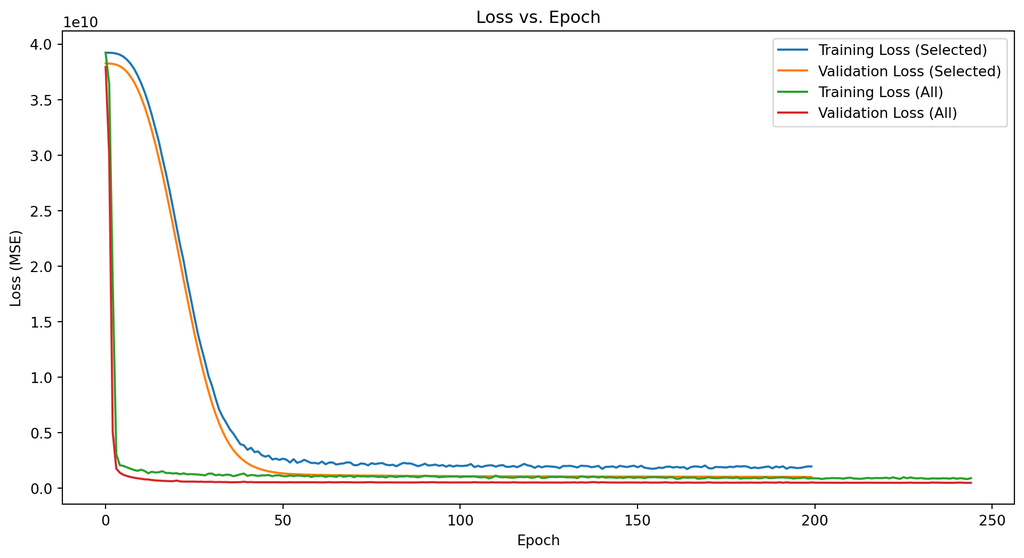

```python
### Plot Loss vs. Epoch
plt.figure(figsize=(12, 6))
plt.plot(history_selected.history['loss'], label='Training Loss (Selected)')
plt.plot(history_selected.history['val_loss'], label='Validation Loss (Selected)')
plt.plot(history_all.history['loss'], label='Training Loss (All)')
plt.plot(history_all.history['val_loss'], label='Validation Loss (All)')
plt.xlabel('Epoch')
plt.ylabel('Loss (MSE)')
plt.legend()
plt.title('Loss vs. Epoch')
plt.show()
```

### **Enhancing Deep Learning Model Performance: Key Lessons**

1. **Handling Missing Data**
   - The original model suffered from NaN loss due to missing values in the dataset.
   - We added **imputation** using the median for numerical features and the most frequent value for categorical features.
2. **Regularization to Improve Generalization**
   - To prevent overfitting, we applied **L2 weight regularization** to dense layers. L2 weight regularization, often called Ridge Regularization, adds a penalty term to the model’s loss function based on the square of the weights. This discourages the weights from growing too large during training, which can help prevent overfitting. By keeping the model simpler and less sensitive to noise in the data, L2 regularization improves generalization to unseen data.
   - **Dropout layers** (20%-30%) were introduced to randomly deactivate neurons during training, improving robustness.
3. **Optimized Training with Early Stopping**
   - We added **early stopping**, which monitors validation loss and halts training if performance stops improving. This prevents unnecessary epochs that could degrade generalization.
4. **Scaling and Encoding for Stable Training**
   - We used **StandardScaler** for numerical features to ensure balanced weight updates during training.
   - **OneHotEncoder** was applied to categorical variables with proper handling of unseen categories to prevent errors.

### **Results**

After implementing these improvements, the deep learning model using all features outperformed both the selected-feature model and linear regression, demonstrating the importance of proper data preprocessing, regularization, and training control.

Through this real-world AI application case in Civil Engineering, you learn how deep learning models require thoughtful feature engineering, meticulous preprocessing, and effective regularization techniques to fully leverage complex datasets.